# Predict Bike Sharing Demand with AutoGluon Template

## Project: Predict Bike Sharing Demand with AutoGluon

This notebook is a template with each step that you need to complete for the project.

Please fill in your code where there are explicit `?` markers in the notebook. You are welcome to add more cells and code as you see fit.

Once you have completed all the code implementations, please export your notebook as a HTML file so the reviews can view your code. Make sure you have all outputs correctly outputted.

`File-> Export Notebook As... -> Export Notebook as HTML`

There is a writeup to complete as well after all code implememtation is done. Please answer all questions and attach the necessary tables and charts. You can complete the writeup in either markdown or PDF.

Completing the code template and writeup template will cover all of the rubric points for this project.

The rubric contains "Stand Out Suggestions" for enhancing the project beyond the minimum requirements. The stand out suggestions are optional. If you decide to pursue the "stand out suggestions", you can include the code in this notebook and also discuss the results in the writeup file.

## Step 1: Create an account with Kaggle

### Create Kaggle Account and download API key

Below is example of steps to get the API username and key. Each student will have their own username and key.

1. Open account settings.

2. Scroll down to API and click Create New API Token.

3. Open up `kaggle.json` and use the username and key.


## Step 2: Download the Kaggle dataset using the kaggle python library

### Open up Sagemaker Studio and use starter template

1. Notebook should be using a `ml.t3.medium` instance (2 vCPU + 4 GiB)
2. Notebook should be using kernal: `Python 3 (MXNet 1.9 Python 3.8 CPU Optimized)`

### Install packages

```python
!pip install -U pip
!pip install -U setuptools wheel
!pip install -U "mxnet<2.0.0" bokeh==2.0.1
!pip install autogluon --no-cache-dir
# Without --no-cache-dir, smaller aws instances may have trouble installing
!pip install kaggle
```

[output not shown]

[output cut: 114 more lines]

[output not shown]

### Setup Kaggle API Key

```python
# create the .kaggle directory and an empty kaggle.json file
!mkdir -p /root/.kaggle
!touch /root/.kaggle/kaggle.json
!chmod 600 /root/.kaggle/kaggle.json
```

```python
!pip install python-dotenv
from dotenv import dotenv_values

CONFIG = dotenv_values('.env')

kaggle_username = CONFIG['KAGGLE_USERNAME']
kaggle_key = CONFIG['KAGGLE_KEY']
```

```
WARNING: Running pip as the 'root' user can result in broken permissions and conflicting behaviour with the system package manager. It is recommended to use a virtual environment instead: https://pip.pypa.io/warnings/venv
```

```python
# Fill in your user name and key from creating the kaggle account and API token file
import json
# Save API token the kaggle.json file
with open("/root/.kaggle/kaggle.json", "w") as f:
    f.write(json.dumps({"username": kaggle_username, "key": kaggle_key}))
```

### Download and explore dataset

### Go to the bike sharing demand competition and agree to the terms

```python
# Download the dataset, it will be in a .zip file so you'll need to unzip it as well.
!kaggle competitions download -c bike-sharing-demand
# If you already downloaded it you can use the -o command to overwrite the file
!unzip -o bike-sharing-demand.zip
```

```
Downloading bike-sharing-demand.zip to /root/Bike-Sharing-Autogluon/project
Archive:  bike-sharing-demand.zip
  inflating: sampleSubmission.csv
  inflating: test.csv
  inflating: train.csv
```

```python
import pandas as pd
from autogluon.tabular import TabularPredictor
import matplotlib.pyplot as plt
import numpy as np
plt.style.use('seaborn-whitegrid')
```

```python
# Create the train dataset in pandas by reading the csv
# Set the parsing of the datetime column so you can use some of the `dt` features in pandas later
train = pd.read_csv('train.csv', parse_dates = ['datetime'])
train.head()
```

|  | datetime | season | holiday | workingday | weather | temp | atemp | humidity | windspeed | casual | registered | count |
| --- | --- | --- | --- | --- | --- | --- | --- | --- | --- | --- | --- | --- |
| 0 | 2011-01-01 00:00:00 | 1 | 0 | 0 | 1 | 9.84 | 14.395 | 81 | 0.0 | 3 | 13 | 16 |
| 1 | 2011-01-01 01:00:00 | 1 | 0 | 0 | 1 | 9.02 | 13.635 | 80 | 0.0 | 8 | 32 | 40 |
| 2 | 2011-01-01 02:00:00 | 1 | 0 | 0 | 1 | 9.02 | 13.635 | 80 | 0.0 | 5 | 27 | 32 |
| 3 | 2011-01-01 03:00:00 | 1 | 0 | 0 | 1 | 9.84 | 14.395 | 75 | 0.0 | 3 | 10 | 13 |
| 4 | 2011-01-01 04:00:00 | 1 | 0 | 0 | 1 | 9.84 | 14.395 | 75 | 0.0 | 0 | 1 | 1 |

```python
# Create the test pandas dataframe in pandas by reading the csv, remember to parse the datetime!
test = pd.read_csv('test.csv', parse_dates = ['datetime'])
test.head()
```

|  | datetime | season | holiday | workingday | weather | temp | atemp | humidity | windspeed |
| --- | --- | --- | --- | --- | --- | --- | --- | --- | --- |
| 0 | 2011-01-20 00:00:00 | 1 | 0 | 1 | 1 | 10.66 | 11.365 | 56 | 26.0027 |
| 1 | 2011-01-20 01:00:00 | 1 | 0 | 1 | 1 | 10.66 | 13.635 | 56 | 0.0000 |
| 2 | 2011-01-20 02:00:00 | 1 | 0 | 1 | 1 | 10.66 | 13.635 | 56 | 0.0000 |
| 3 | 2011-01-20 03:00:00 | 1 | 0 | 1 | 1 | 10.66 | 12.880 | 56 | 11.0014 |
| 4 | 2011-01-20 04:00:00 | 1 | 0 | 1 | 1 | 10.66 | 12.880 | 56 | 11.0014 |

```python
# Same thing as train and test dataset
submission = pd.read_csv('sampleSubmission.csv', parse_dates = ["datetime"])
submission.head()
```

|  | datetime | count |
| --- | --- | --- |
| 0 | 2011-01-20 00:00:00 | 0 |
| 1 | 2011-01-20 01:00:00 | 0 |
| 2 | 2011-01-20 02:00:00 | 0 |
| 3 | 2011-01-20 03:00:00 | 0 |
| 4 | 2011-01-20 04:00:00 | 0 |

```python
train.info()
```

```
<class 'pandas.core.frame.DataFrame'>
RangeIndex: 10886 entries, 0 to 10885
Data columns (total 12 columns):
 #   Column      Non-Null Count  Dtype
---  ------      --------------  -----
 0   datetime    10886 non-null  datetime64[ns]
 1   season      10886 non-null  int64
 2   holiday     10886 non-null  int64
 3   workingday  10886 non-null  int64
 4   weather     10886 non-null  int64
 5   temp        10886 non-null  float64
 6   atemp       10886 non-null  float64
 7   humidity    10886 non-null  int64
 8   windspeed   10886 non-null  float64
 9   casual      10886 non-null  int64
 10  registered  10886 non-null  int64
 11  count       10886 non-null  int64
dtypes: datetime64[ns](1), float64(3), int64(8)
memory usage: 1020.7 KB
```

```python
# Simple output of the train dataset to view some of the min/max/varition of the dataset features.
train.describe()
```

|  | season | holiday | workingday | weather | temp | atemp | humidity | windspeed | casual | registered | count |
| --- | --- | --- | --- | --- | --- | --- | --- | --- | --- | --- | --- |
| count | 10886.000000 | 10886.000000 | 10886.000000 | 10886.000000 | 10886.00000 | 10886.000000 | 10886.000000 | 10886.000000 | 10886.000000 | 10886.000000 | 10886.000000 |
| mean | 2.506614 | 0.028569 | 0.680875 | 1.418427 | 20.23086 | 23.655084 | 61.886460 | 12.799395 | 36.021955 | 155.552177 | 191.574132 |
| std | 1.116174 | 0.166599 | 0.466159 | 0.633839 | 7.79159 | 8.474601 | 19.245033 | 8.164537 | 49.960477 | 151.039033 | 181.144454 |
| min | 1.000000 | 0.000000 | 0.000000 | 1.000000 | 0.82000 | 0.760000 | 0.000000 | 0.000000 | 0.000000 | 0.000000 | 1.000000 |
| 25% | 2.000000 | 0.000000 | 0.000000 | 1.000000 | 13.94000 | 16.665000 | 47.000000 | 7.001500 | 4.000000 | 36.000000 | 42.000000 |
| 50% | 3.000000 | 0.000000 | 1.000000 | 1.000000 | 20.50000 | 24.240000 | 62.000000 | 12.998000 | 17.000000 | 118.000000 | 145.000000 |
| 75% | 4.000000 | 0.000000 | 1.000000 | 2.000000 | 26.24000 | 31.060000 | 77.000000 | 16.997900 | 49.000000 | 222.000000 | 284.000000 |
| max | 4.000000 | 1.000000 | 1.000000 | 4.000000 | 41.00000 | 45.455000 | 100.000000 | 56.996900 | 367.000000 | 886.000000 | 977.000000 |

Let's first create some data visualizations to get an understanding of the data.

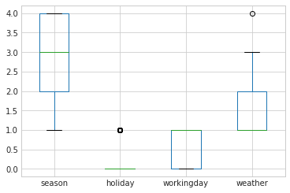

```python
train.loc[:, ['season', 'holiday', 'workingday', 'weather']].boxplot()
plt.show()
```

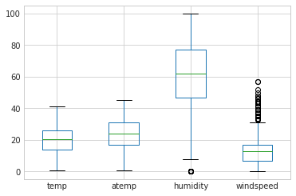

```python
train.loc[:, ['temp','atemp','humidity', 'windspeed']].boxplot()
plt.show()
```

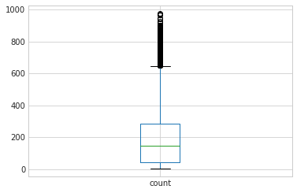

```python
train.loc[:, ['count']].boxplot()
plt.show()
```

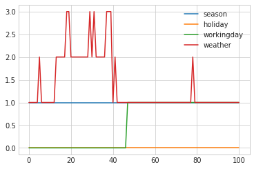

```python
train.loc[:100, ['season', 'holiday', 'workingday', 'weather']].plot()
plt.show()
```

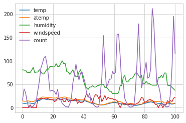

```python
train.loc[:100, ['temp','atemp','humidity', 'windspeed', 'count']].plot()
plt.show()
```

The statistics and visualizations above indicate that humidity and windspeed have minimum values of zero.

- A zero humidity is unrealistic. Therefore, it likely represents missing data.
- While a zero windspeed can indicate calm weather, it seems to be an unusual value, given that windspeed can be reported at floating point precision.

Let's treat these zero values as missing data and impute them. Here I will use a simple K-nearest neighbor imputation scheme.

```python
train['humidity'] = train['humidity'].replace(0,np.nan)
train['windspeed'] = train['windspeed'].replace(0,np.nan)
test['humidity'] = test['humidity'].replace(0,np.nan)
test['windspeed'] = test['windspeed'].replace(0,np.nan)
```

```python
# from https://machinelearningmastery.com/knn-imputation-for-missing-values-in-machine-learning/
from sklearn.impute import KNNImputer
# define imputer
imputer = KNNImputer(n_neighbors=5, weights='uniform', metric='nan_euclidean')
# fit on the dataset
impute_features = ['season', 'holiday', 'workingday', 'weather', 'temp',
       'atemp', 'humidity', 'windspeed']
imputer.fit(train.loc[:,impute_features])
```

```
KNNImputer()
```

```python
# transform the dataset
train_imputed = pd.DataFrame(imputer.transform(train.loc[:,impute_features]), columns = impute_features)
test_imputed = pd.DataFrame(imputer.transform(test.loc[:,impute_features]), columns = impute_features)
train['humidity'] = train_imputed['humidity']
train['windspeed'] = train_imputed['windspeed']
test['humidity'] = test_imputed['humidity']
test['windspeed'] = test_imputed['windspeed']
```

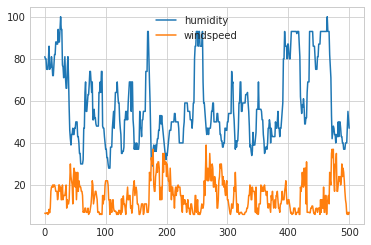

```python
train.loc[:500, ['humidity', 'windspeed']].plot()
plt.show()
```

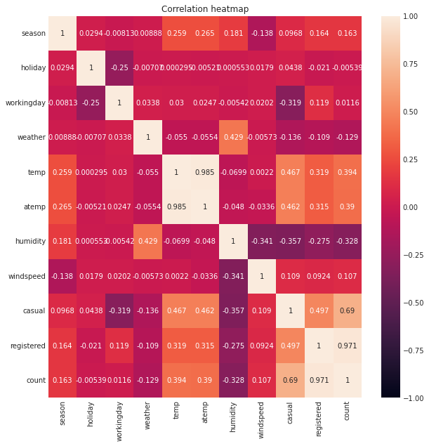

```python
import seaborn as sns
import matplotlib.pyplot as plt
plt.figure(figsize = (10,10))
sns.heatmap(train.corr(), vmin=-1, vmax=1, annot=True, fmt='.3g')
plt.title('Correlation heatmap')
plt.show()
```

The correlation heatmap above shows that 'temp' and 'atemp' are very highly correlcated. It can be helpful to eliminate one these input features from the study to avoid multicollinearity issues. Because 'temp' is more highly correlated with 'count' than 'atemp' I will use 'temp' as the predictor feature.

## Step 3: Train a model using AutoGluon’s Tabular Prediction

Requirements:

- We are prediting `count`, so it is the label we are setting.
- Ignore `casual` and `registered` columns as they are also not present in the test dataset.
- Use the `root_mean_squared_error` as the metric to use for evaluation.
- Set a time limit of 10 minutes (600 seconds).
- Use the preset `best_quality` to focus on creating the best model.

```python
train_col_names = set(train.columns) - {"casual","registered","atemp"}
test_col_names = train_col_names - {"count"}
train_col_names = sorted(train_col_names)
test_col_names = sorted(test_col_names)
print(train_col_names)
print(test_col_names)
```

```
['count', 'datetime', 'holiday', 'humidity', 'season', 'temp', 'weather', 'windspeed', 'workingday']
['datetime', 'holiday', 'humidity', 'season', 'temp', 'weather', 'windspeed', 'workingday']
```

```python
#predictor = TabularPredictor(label = "count", problem_type="regression", eval_metric = "root_mean_squared_error" ,learner_kwargs={"ignored_columns": ["casual", "registered"]}).fit(
#    train_data=train,
#    time_limit=600,
#    presets="best_quality",)

predictor = TabularPredictor(label = "count", problem_type="regression", eval_metric = "root_mean_squared_error").fit(
    train_data=train[train_col_names],
    time_limit=600,
    presets="best_quality",
   )
```

```
No path specified. Models will be saved in: "AutogluonModels/ag-20230205_212616/"
Presets specified: ['best_quality']
Stack configuration (auto_stack=True): num_stack_levels=1, num_bag_folds=8, num_bag_sets=20
Beginning AutoGluon training ... Time limit = 600s
AutoGluon will save models to "AutogluonModels/ag-20230205_212616/"
AutoGluon Version:  0.6.2
Python Version:     3.8.10
Operating System:   Linux
Platform Machine:   x86_64
Platform Version:   #1 SMP Fri Dec 9 09:57:03 UTC 2022
Train Data Rows:    10886
Train Data Columns: 8
Label Column: count
Preprocessing data ...
Using Feature Generators to preprocess the data ...
Fitting AutoMLPipelineFeatureGenerator...
	Available Memory:                    3044.18 MB
	Train Data (Original)  Memory Usage: 0.7 MB (0.0% of available memory)
	Inferring data type of each feature based on column values. Set feature_metadata_in to manually specify special dtypes of the features.
	Stage 1 Generators:
		Fitting AsTypeFeatureGenerator...
			Note: Converting 2 features to boolean dtype as they only contain 2 unique values.
	Stage 2 Generators:
		Fitting FillNaFeatureGenerator...
	Stage 3 Generators:
		Fitting IdentityFeatureGenerator...
		Fitting DatetimeFeatureGenerator...
	Stage 4 Generators:
		Fitting DropUniqueFeatureGenerator...
	Types of features in original data (raw dtype, special dtypes):
		('datetime', []) : 1 | ['datetime']
		('float', [])    : 3 | ['humidity', 'temp', 'windspeed']
		('int', [])      : 4 | ['holiday', 'season', 'weather', 'workingday']
	Types of features in processed data (raw dtype, special dtypes):
		('float', [])                : 3 | ['humidity', 'temp', 'windspeed']
		('int', [])                  : 2 | ['season', 'weather']
		('int', ['bool'])            : 2 | ['holiday', 'workingday']
		('int', ['datetime_as_int']) : 5 | ['datetime', 'datetime.year', 'datetime.month', 'datetime.day', 'datetime.dayofweek']
	0.2s = Fit runtime
	8 features in original data used to generate 12 features in processed data.
```

[output cut: 78 more lines]

```
	Fitting 8 child models (S1F1 - S1F8) | Fitting with ParallelLocalFoldFittingStrategy
	-55.3916	 = Validation score   (-root_mean_squared_error)
	74.32s	 = Training   runtime
	0.05s	 = Validation runtime
Fitting model: ExtraTreesMSE_BAG_L2 ... Training model for up to 7.44s of the 7.43s of remaining time.
	-53.689	 = Validation score   (-root_mean_squared_error)
	7.98s	 = Training   runtime
	0.58s	 = Validation runtime
Completed 1/20 k-fold bagging repeats ...
Fitting model: WeightedEnsemble_L3 ... Training model for up to 360.0s of the -3.63s of remaining time.
	-52.7122	 = Validation score   (-root_mean_squared_error)
	0.3s	 = Training   runtime
	0.0s	 = Validation runtime
AutoGluon training complete, total runtime = 604.12s ... Best model: "WeightedEnsemble_L3"
TabularPredictor saved. To load, use: predictor = TabularPredictor.load("AutogluonModels/ag-20230205_212616/")
```

### Review AutoGluon's training run with ranking of models that did the best.

```python
predictor.fit_summary()
```

```
*** Summary of fit() ***
Estimated performance of each model:
                     model   score_val  pred_time_val    fit_time  pred_time_val_marginal  fit_time_marginal  stack_level  can_infer  fit_order
0      WeightedEnsemble_L3  -52.712174       9.122138  497.345785                0.000695           0.300013            3       True         17
1   RandomForestMSE_BAG_L2  -53.313463       8.267649  393.085148                0.611912          27.810758            2       True         14
2     ExtraTreesMSE_BAG_L2  -53.689047       8.238730  373.251152                0.582993           7.976761            2       True         16
3          LightGBM_BAG_L2  -55.074251       7.875116  386.938009                0.219379          21.663618            2       True         13
4          CatBoost_BAG_L2  -55.391555       7.707159  439.594635                0.051422          74.320245            2       True         15
5        LightGBMXT_BAG_L2  -60.903480      11.043416  416.088950                3.387679          50.814560            2       True         12
6    KNeighborsDist_BAG_L1  -84.125061       0.036410    0.027660                0.036410           0.027660            1       True          2
7      WeightedEnsemble_L2  -84.125061       0.037065    0.531371                0.000654           0.503710            2       True         11
8    KNeighborsUnif_BAG_L1 -101.546199       0.036702    0.029932                0.036702           0.029932            1       True          1
9   RandomForestMSE_BAG_L1 -117.076156       0.530622    9.258194                0.530622           9.258194            1       True          5
10    ExtraTreesMSE_BAG_L1 -124.316314       0.506089    4.358305                0.506089           4.358305            1       True          7
11    LightGBMLarge_BAG_L1 -130.594864       0.753457   29.746351                0.753457          29.746351            1       True         10
12         CatBoost_BAG_L1 -131.031871       0.115164  151.187708                0.115164         151.187708            1       True          6
13          XGBoost_BAG_L1 -131.477969       0.364704   20.375495                0.364704          20.375495            1       True          9
14         LightGBM_BAG_L1 -131.626332       1.138515   22.652047                1.138515          22.652047            1       True          4
15       LightGBMXT_BAG_L1 -132.499729       3.850998   41.357313                3.850998          41.357313            1       True          3
16  NeuralNetFastAI_BAG_L1 -135.542451       0.323076   86.281384                0.323076          86.281384            1       True          8
Number of models trained: 17
Types of models trained:
{'StackerEnsembleModel_RF', 'StackerEnsembleModel_LGB', 'StackerEnsembleModel_NNFastAiTabular', 'StackerEnsembleModel_CatBoost', 'StackerEnsembleModel_KNN', 'StackerEnsembleModel_XT', 'StackerEnsembleModel_XGBoost', 'WeightedEnsembleModel'}
Bagging used: True  (with 8 folds)
Multi-layer stack-ensembling used: True  (with 3 levels)
Feature Metadata (Processed):
(raw dtype, special dtypes):
('float', [])                : 3 | ['humidity', 'temp', 'windspeed']
('int', [])                  : 2 | ['season', 'weather']
('int', ['bool'])            : 2 | ['holiday', 'workingday']
('int', ['datetime_as_int']) : 5 | ['datetime', 'datetime.year', 'datetime.month', 'datetime.day', 'datetime.dayofweek']
Plot summary of models saved to file: AutogluonModels/ag-20230205_212616/SummaryOfModels.html
*** End of fit() summary ***
```

[output not shown]

[output cut: 163 more lines]

[output not shown]

### Create predictions from test dataset

```python
predictions = predictor.predict(test[test_col_names])
predictions.head()
```

```
0    22.514494
1    39.239639
2    44.330986
3    48.509926
4    51.616432
Name: count, dtype: float32
```

#### NOTE: Kaggle will reject the submission if we don't set everything to be > 0.

```python
# Describe the `predictions` series to see if there are any negative values
predictions.describe()
```

```
count    6493.000000
mean      100.580704
std        90.334167
min         3.064677
25%        19.727165
50%        62.939091
75%       172.081314
max       360.809265
Name: count, dtype: float64
```

```python
# How many negative values do we have?
# because the min value above is greater than 0, it is evident that there are no negatives in this case.
# completing the following steps for the sake of completeness
sum(predictions<0)
```

```
0
```

```python
# Set them to zero
predictions[predictions<0] = 0
```

### Set predictions to submission dataframe, save, and submit

```python
submission["count"] = predictions
submission.to_csv("submission.csv", index=False)
```

```python
!kaggle competitions submit -c bike-sharing-demand -f submission.csv -m "first raw submission"
```

```
Successfully submitted to Bike Sharing Demand
```

#### View submission via the command line or in the web browser under the competition's page - `My Submissions`

```python
!kaggle competitions submissions -c bike-sharing-demand | tail -n +1 | head -n 3
```

```
fileName                        date                 description                           status    publicScore  privateScore
------------------------------  -------------------  ------------------------------------  --------  -----------  ------------
submission.csv                  2023-02-05 21:36:44  first raw submission                  complete  1.80822      1.80822
tail: write error: Broken pipe
```

#### Initial score of 1.80822

## Step 4: Exploratory Data Analysis and Creating an additional feature

- Any additional feature will do, but a great suggestion would be to separate out the datetime into hour, day, or month parts.

```
array([[<AxesSubplot:title={'center':'datetime'}>,
        <AxesSubplot:title={'center':'season'}>,
        <AxesSubplot:title={'center':'holiday'}>],
       [<AxesSubplot:title={'center':'workingday'}>,
        <AxesSubplot:title={'center':'weather'}>,
        <AxesSubplot:title={'center':'temp'}>],
       [<AxesSubplot:title={'center':'atemp'}>,
        <AxesSubplot:title={'center':'humidity'}>,
        <AxesSubplot:title={'center':'windspeed'}>],
       [<AxesSubplot:title={'center':'casual'}>,
        <AxesSubplot:title={'center':'registered'}>,
        <AxesSubplot:title={'center':'count'}>]], dtype=object)
```

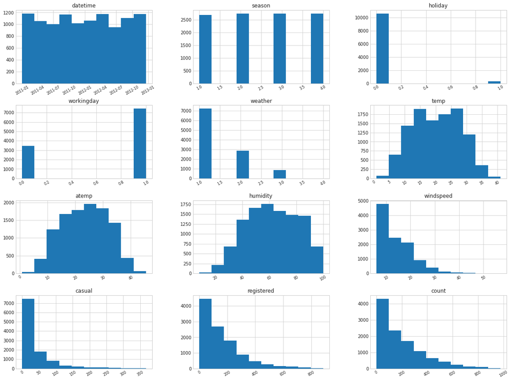

```python
# Create a histogram of all features to show the distribution of each one relative to the data. This is part of the exploritory data analysis
train.hist(xlabelsize = 8, xrot =30, figsize = (20,15))
```

```python
print(predictor.feature_metadata)
```

```
('float', [])                : 3 | ['humidity', 'temp', 'windspeed']
('int', [])                  : 2 | ['season', 'weather']
('int', ['bool'])            : 2 | ['holiday', 'workingday']
('int', ['datetime_as_int']) : 5 | ['datetime', 'datetime.year', 'datetime.month', 'datetime.day', 'datetime.dayofweek']
```

Based on the previously fit predictor, AutoGluon treated ['datetime', 'datetime.year', 'datetime.month', 'datetime.day', 'datetime.dayofweek'] as 5 separate input features. Let's use the hour information as an additional input feature. Given that time is a cyclic variable, it can be desirable to represent it as a categorical variable than a continuous integer variable.

```python
# create a new feature
train['hour'] = train['datetime'].dt.hour.astype("category")
test['hour'] = test['datetime'].dt.hour.astype("category")

train['day'] = train['datetime'].dt.day.astype("category")
test['day'] = test['datetime'].dt.day.astype("category")

train['month'] = train['datetime'].dt.month.astype("category")
test['month'] = test['datetime'].dt.month.astype("category")

train['year'] = train['datetime'].dt.year.astype("category")
test['year'] = test['datetime'].dt.year.astype("category")

train['day_of_week'] = train['datetime'].dt.weekday.astype("category")
test['day_of_week'] = test['datetime'].dt.weekday.astype("category")
```

## Make category types for these so models know they are not just numbers

- AutoGluon originally sees these as ints, but in reality they are int representations of a category.
- Setting the dtype to category will classify these as categories in AutoGluon.

```python
train["season"] = train["season"].astype("category")
train["weather"] = train["weather"].astype("category")
test["season"] = test["season"].astype("category")
test["weather"] = test["weather"].astype("category")
```

```python
# View new feature
train.head()
```

|  | datetime | season | holiday | workingday | weather | temp | atemp | humidity | windspeed | casual | registered | count | hour | day | month | year | day_of_week |
| --- | --- | --- | --- | --- | --- | --- | --- | --- | --- | --- | --- | --- | --- | --- | --- | --- | --- |
| 0 | 2011-01-01 00:00:00 | 1 | 0 | 0 | 1 | 9.84 | 14.395 | 81.0 | 6.60218 | 3 | 13 | 16 | 0 | 1 | 1 | 2011 | 5 |
| 1 | 2011-01-01 01:00:00 | 1 | 0 | 0 | 1 | 9.02 | 13.635 | 80.0 | 6.40252 | 8 | 32 | 40 | 1 | 1 | 1 | 2011 | 5 |
| 2 | 2011-01-01 02:00:00 | 1 | 0 | 0 | 1 | 9.02 | 13.635 | 80.0 | 6.40252 | 5 | 27 | 32 | 2 | 1 | 1 | 2011 | 5 |
| 3 | 2011-01-01 03:00:00 | 1 | 0 | 0 | 1 | 9.84 | 14.395 | 75.0 | 6.80184 | 3 | 10 | 13 | 3 | 1 | 1 | 2011 | 5 |
| 4 | 2011-01-01 04:00:00 | 1 | 0 | 0 | 1 | 9.84 | 14.395 | 75.0 | 6.80184 | 0 | 1 | 1 | 4 | 1 | 1 | 2011 | 5 |

```python
train.info()
```

```
<class 'pandas.core.frame.DataFrame'>
RangeIndex: 10886 entries, 0 to 10885
Data columns (total 17 columns):
 #   Column       Non-Null Count  Dtype
---  ------       --------------  -----
 0   datetime     10886 non-null  datetime64[ns]
 1   season       10886 non-null  category
 2   holiday      10886 non-null  int64
 3   workingday   10886 non-null  int64
 4   weather      10886 non-null  category
 5   temp         10886 non-null  float64
 6   atemp        10886 non-null  float64
 7   humidity     10886 non-null  float64
 8   windspeed    10886 non-null  float64
 9   casual       10886 non-null  int64
 10  registered   10886 non-null  int64
 11  count        10886 non-null  int64
 12  hour         10886 non-null  category
 13  day          10886 non-null  category
 14  month        10886 non-null  category
 15  year         10886 non-null  category
 16  day_of_week  10886 non-null  category
dtypes: category(7), datetime64[ns](1), float64(4), int64(5)
memory usage: 927.7 KB
```

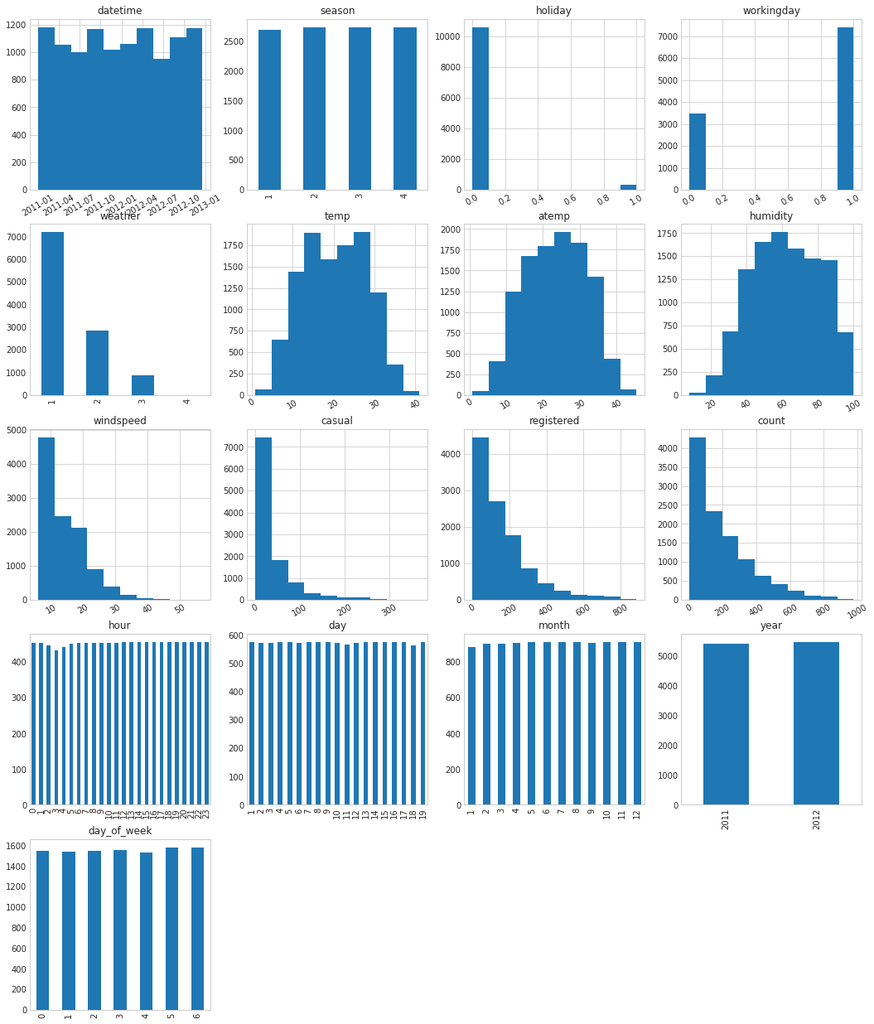

```python
# View histogram of all features
import matplotlib.pyplot as plt
plt.figure(figsize = (18,22))
for i,variable in enumerate(train.columns):
    plt.subplot(5,4,i+1)
    if train[variable].dtype.name == 'category':
        train[variable].value_counts(sort = False).plot.bar()
        plt.grid()
    else:
        train[variable].hist(xrot = 30)
    plt.title(variable)
plt.show()
```

## Step 5: Rerun the model with the same settings as before, just with more features

```python
train_col_names_1 = set(train.columns) - {"casual","registered","datetime","atemp"} # datetime information was separated to different columns before
test_col_names_1 = train_col_names_1 - {"count"}

train_col_names_1 =sorted(train_col_names_1)
test_col_names_1 =sorted(test_col_names_1)
print(train_col_names_1)
print(test_col_names_1)
```

```
['count', 'day', 'day_of_week', 'holiday', 'hour', 'humidity', 'month', 'season', 'temp', 'weather', 'windspeed', 'workingday', 'year']
['day', 'day_of_week', 'holiday', 'hour', 'humidity', 'month', 'season', 'temp', 'weather', 'windspeed', 'workingday', 'year']
```

```python
predictor_new_features = TabularPredictor(label = "count", problem_type="regression", eval_metric = "root_mean_squared_error" ).fit(
    train_data=train[train_col_names_1],
    time_limit=600,
    presets="best_quality",)
```

```
No path specified. Models will be saved in: "AutogluonModels/ag-20230205_213650/"
Presets specified: ['best_quality']
Stack configuration (auto_stack=True): num_stack_levels=1, num_bag_folds=8, num_bag_sets=20
Beginning AutoGluon training ... Time limit = 600s
AutoGluon will save models to "AutogluonModels/ag-20230205_213650/"
AutoGluon Version:  0.6.2
Python Version:     3.8.10
Operating System:   Linux
Platform Machine:   x86_64
Platform Version:   #1 SMP Fri Dec 9 09:57:03 UTC 2022
Train Data Rows:    10886
Train Data Columns: 12
Label Column: count
Preprocessing data ...
Using Feature Generators to preprocess the data ...
Fitting AutoMLPipelineFeatureGenerator...
	Available Memory:                    1789.74 MB
	Train Data (Original)  Memory Usage: 0.51 MB (0.0% of available memory)
	Inferring data type of each feature based on column values. Set feature_metadata_in to manually specify special dtypes of the features.
	Stage 1 Generators:
		Fitting AsTypeFeatureGenerator...
			Note: Converting 3 features to boolean dtype as they only contain 2 unique values.
	Stage 2 Generators:
		Fitting FillNaFeatureGenerator...
	Stage 3 Generators:
		Fitting IdentityFeatureGenerator...
		Fitting CategoryFeatureGenerator...
			Fitting CategoryMemoryMinimizeFeatureGenerator...
	Stage 4 Generators:
		Fitting DropUniqueFeatureGenerator...
	Types of features in original data (raw dtype, special dtypes):
		('category', []) : 7 | ['day', 'day_of_week', 'hour', 'month', 'season', ...]
		('float', [])    : 3 | ['humidity', 'temp', 'windspeed']
		('int', [])      : 2 | ['holiday', 'workingday']
	Types of features in processed data (raw dtype, special dtypes):
		('category', [])  : 6 | ['day', 'day_of_week', 'hour', 'month', 'season', ...]
		('float', [])     : 3 | ['humidity', 'temp', 'windspeed']
		('int', ['bool']) : 3 | ['holiday', 'workingday', 'year']
	0.1s = Fit runtime
	12 features in original data used to generate 12 features in processed data.
```

[output cut: 69 more lines]

```
	-34.0095	 = Validation score   (-root_mean_squared_error)
	7.83s	 = Training   runtime
	0.59s	 = Validation runtime
Fitting model: NeuralNetFastAI_BAG_L2 ... Training model for up to 7.22s of the 7.21s of remaining time.
	Fitting 8 child models (S1F1 - S1F8) | Fitting with ParallelLocalFoldFittingStrategy
	-44.0171	 = Validation score   (-root_mean_squared_error)
	26.11s	 = Training   runtime
	0.43s	 = Validation runtime
Completed 1/20 k-fold bagging repeats ...
Fitting model: WeightedEnsemble_L3 ... Training model for up to 360.0s of the -21.92s of remaining time.
	-33.6299	 = Validation score   (-root_mean_squared_error)
	0.41s	 = Training   runtime
	0.0s	 = Validation runtime
AutoGluon training complete, total runtime = 622.52s ... Best model: "WeightedEnsemble_L3"
TabularPredictor saved. To load, use: predictor = TabularPredictor.load("AutogluonModels/ag-20230205_213650/")
```

```python
predictor_new_features.fit_summary()
```

```
*** Summary of fit() ***
Estimated performance of each model:
                     model   score_val  pred_time_val    fit_time  pred_time_val_marginal  fit_time_marginal  stack_level  can_infer  fit_order
0      WeightedEnsemble_L3  -33.629944      18.205161  559.200237                0.001011           0.406836            3       True         16
1      WeightedEnsemble_L2  -33.810380      15.417781  350.748985                0.001017           0.432299            2       True          9
2          CatBoost_BAG_L2  -33.941110      16.019486  480.008285                0.167987          84.150749            2       True         13
3     ExtraTreesMSE_BAG_L2  -34.009460      16.443127  403.682597                0.591628           7.825061            2       True         14
4          LightGBM_BAG_L2  -34.136704      15.995803  415.307552                0.144304          19.450016            2       True         11
5   RandomForestMSE_BAG_L2  -34.477682      16.872314  421.253678                1.020815          25.396142            2       True         12
6        LightGBMXT_BAG_L1  -34.832287      10.286656   68.175730               10.286656          68.175730            1       True          3
7        LightGBMXT_BAG_L2  -34.881486      16.306075  417.602476                0.454575          21.744940            2       True         10
8          LightGBM_BAG_L1  -35.980582       3.664369   41.495182                3.664369          41.495182            1       True          4
9     ExtraTreesMSE_BAG_L1  -37.902092       0.540133    4.842701                0.540133           4.842701            1       True          7
10  RandomForestMSE_BAG_L1  -39.174850       0.552451    8.619319                0.552451           8.619319            1       True          5
11         CatBoost_BAG_L1  -39.185614       0.373156  227.183755                0.373156         227.183755            1       True          6
12  NeuralNetFastAI_BAG_L1  -40.882232       0.362838   45.509797                0.362838          45.509797            1       True          8
13  NeuralNetFastAI_BAG_L2  -44.017123      16.279418  421.971433                0.427918          26.113897            2       True         15
14   KNeighborsUnif_BAG_L1 -164.786141       0.035029    0.014416                0.035029           0.014416            1       True          1
15   KNeighborsDist_BAG_L1 -179.308610       0.036869    0.016637                0.036869           0.016637            1       True          2
Number of models trained: 16
Types of models trained:
{'StackerEnsembleModel_RF', 'StackerEnsembleModel_LGB', 'StackerEnsembleModel_NNFastAiTabular', 'StackerEnsembleModel_CatBoost', 'StackerEnsembleModel_KNN', 'StackerEnsembleModel_XT', 'WeightedEnsembleModel'}
Bagging used: True  (with 8 folds)
Multi-layer stack-ensembling used: True  (with 3 levels)
Feature Metadata (Processed):
(raw dtype, special dtypes):
('category', [])  : 6 | ['day', 'day_of_week', 'hour', 'month', 'season', ...]
('float', [])     : 3 | ['humidity', 'temp', 'windspeed']
('int', ['bool']) : 3 | ['holiday', 'workingday', 'year']
Plot summary of models saved to file: AutogluonModels/ag-20230205_213650/SummaryOfModels.html
*** End of fit() summary ***
```

[output not shown]

[output cut: 151 more lines]

[output not shown]

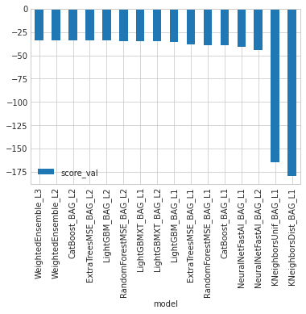

```python
# Output the model's `score_val` in a bar chart to compare performance
predictor_new_features.leaderboard(silent=True).plot(kind="bar", x="model", y="score_val")
plt.show()
```

```python
# Remember to set all negative values to zero
new_predictions = predictor_new_features.predict(test[test_col_names_1])
new_predictions[new_predictions<0] = 0
new_predictions.head()
```

```
0    8.707143
1    4.762201
2    4.485944
3    3.524846
4    3.527802
Name: count, dtype: float32
```

```python
# Same submitting predictions
submission_new_features = pd.read_csv("sampleSubmission.csv", parse_dates=["datetime"])
submission_new_features["count"] = new_predictions
submission_new_features.to_csv("submission_new_features.csv", index=False)
```

```python
!kaggle competitions submit -c bike-sharing-demand -f submission_new_features.csv -m "new features"
```

```
Successfully submitted to Bike Sharing Demand
```

```python
!kaggle competitions submissions -c bike-sharing-demand | tail -n +1 | head -n 4
```

```
fileName                        date                 description                           status    publicScore  privateScore
------------------------------  -------------------  ------------------------------------  --------  -----------  ------------
submission_new_features.csv     2023-02-05 21:47:52  new features                          complete  0.43710      0.43710
submission.csv                  2023-02-05 21:36:44  first raw submission                  complete  1.80822      1.80822
tail: write error: Broken pipe
```

#### New Score of 0.43710

## STEP 5 i) Transformation of the predictand

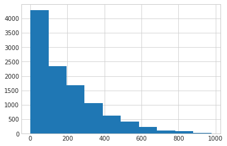

```python
plt.hist(train['count'])
plt.show()
```

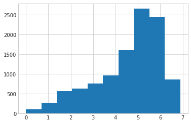

```python
plt.hist(np.log(train['count']))
plt.show()
```

```python
train['log_count'] = np.log(train['count'])
```

The count data is skew distributed. Log transforming it makes the data more normally distributed.

```python
train_col_names_2 = set(train.columns) - {"casual","registered","datetime","atemp","count"} # datetime information was separated to different columns before
test_col_names_2 = train_col_names_2 - {"log_count"}

train_col_names_2 =sorted(train_col_names_2)
test_col_names_2 =sorted(test_col_names_2)
print(train_col_names_2)
print(test_col_names_2)
```

```
['day', 'day_of_week', 'holiday', 'hour', 'humidity', 'log_count', 'month', 'season', 'temp', 'weather', 'windspeed', 'workingday', 'year']
['day', 'day_of_week', 'holiday', 'hour', 'humidity', 'month', 'season', 'temp', 'weather', 'windspeed', 'workingday', 'year']
```

```python
predictor_log = TabularPredictor(label = "log_count", problem_type="regression", eval_metric = "root_mean_squared_error").fit(
    train_data=train[train_col_names_2],
    time_limit=600,
    presets="best_quality",)
```

```
No path specified. Models will be saved in: "AutogluonModels/ag-20230205_214754/"
Presets specified: ['best_quality']
Stack configuration (auto_stack=True): num_stack_levels=1, num_bag_folds=8, num_bag_sets=20
Beginning AutoGluon training ... Time limit = 600s
AutoGluon will save models to "AutogluonModels/ag-20230205_214754/"
AutoGluon Version:  0.6.2
Python Version:     3.8.10
Operating System:   Linux
Platform Machine:   x86_64
Platform Version:   #1 SMP Fri Dec 9 09:57:03 UTC 2022
Train Data Rows:    10886
Train Data Columns: 12
Label Column: log_count
Preprocessing data ...
Using Feature Generators to preprocess the data ...
Fitting AutoMLPipelineFeatureGenerator...
	Available Memory:                    2055.44 MB
	Train Data (Original)  Memory Usage: 0.51 MB (0.0% of available memory)
	Inferring data type of each feature based on column values. Set feature_metadata_in to manually specify special dtypes of the features.
	Stage 1 Generators:
		Fitting AsTypeFeatureGenerator...
			Note: Converting 3 features to boolean dtype as they only contain 2 unique values.
	Stage 2 Generators:
		Fitting FillNaFeatureGenerator...
	Stage 3 Generators:
		Fitting IdentityFeatureGenerator...
		Fitting CategoryFeatureGenerator...
			Fitting CategoryMemoryMinimizeFeatureGenerator...
	Stage 4 Generators:
		Fitting DropUniqueFeatureGenerator...
	Types of features in original data (raw dtype, special dtypes):
		('category', []) : 7 | ['day', 'day_of_week', 'hour', 'month', 'season', ...]
		('float', [])    : 3 | ['humidity', 'temp', 'windspeed']
		('int', [])      : 2 | ['holiday', 'workingday']
	Types of features in processed data (raw dtype, special dtypes):
		('category', [])  : 6 | ['day', 'day_of_week', 'hour', 'month', 'season', ...]
		('float', [])     : 3 | ['humidity', 'temp', 'windspeed']
		('int', ['bool']) : 3 | ['holiday', 'workingday', 'year']
	0.1s = Fit runtime
	12 features in original data used to generate 12 features in processed data.
```

[output cut: 69 more lines]

```
	-0.2982	 = Validation score   (-root_mean_squared_error)
	7.8s	 = Training   runtime
	0.6s	 = Validation runtime
Fitting model: NeuralNetFastAI_BAG_L2 ... Training model for up to 11.64s of the 11.62s of remaining time.
	Fitting 8 child models (S1F1 - S1F8) | Fitting with ParallelLocalFoldFittingStrategy
	-0.3694	 = Validation score   (-root_mean_squared_error)
	27.73s	 = Training   runtime
	0.45s	 = Validation runtime
Completed 1/20 k-fold bagging repeats ...
Fitting model: WeightedEnsemble_L3 ... Training model for up to 360.0s of the -19.26s of remaining time.
	-0.2947	 = Validation score   (-root_mean_squared_error)
	0.32s	 = Training   runtime
	0.0s	 = Validation runtime
AutoGluon training complete, total runtime = 619.77s ... Best model: "WeightedEnsemble_L2"
TabularPredictor saved. To load, use: predictor = TabularPredictor.load("AutogluonModels/ag-20230205_214754/")
```

```python
predictor_log.fit_summary()
```

```
*** Summary of fit() ***
Estimated performance of each model:
                     model  score_val  pred_time_val    fit_time  pred_time_val_marginal  fit_time_marginal  stack_level  can_infer  fit_order
0      WeightedEnsemble_L2  -0.294038       5.600609  394.421721                0.001007           0.714769            2       True          9
1      WeightedEnsemble_L3  -0.294661       7.275942  532.829397                0.000733           0.324325            3       True         16
2          CatBoost_BAG_L2  -0.295844       5.812274  476.096422                0.135980          82.355148            2       True         13
3     ExtraTreesMSE_BAG_L2  -0.298166       6.277263  401.541231                0.600969           7.799957            2       True         14
4        LightGBMXT_BAG_L2  -0.300011       6.083482  414.623450                0.407187          20.882175            2       True         10
5        LightGBMXT_BAG_L1  -0.300248       2.184632   29.983429                2.184632          29.983429            1       True          3
6          LightGBM_BAG_L2  -0.300327       5.811972  413.814006                0.135678          20.072732            2       True         11
7   RandomForestMSE_BAG_L2  -0.302424       6.304467  419.957859                0.628173          26.216584            2       True         12
8          LightGBM_BAG_L1  -0.309205       1.441087   24.821206                1.441087          24.821206            1       True          4
9     ExtraTreesMSE_BAG_L1  -0.318369       0.595752    4.738853                0.595752           4.738853            1       True          7
10  NeuralNetFastAI_BAG_L1  -0.321715       0.375219   53.837714                0.375219          53.837714            1       True          8
11         CatBoost_BAG_L1  -0.322601       0.433190  271.044665                0.433190         271.044665            1       True          6
12  RandomForestMSE_BAG_L1  -0.324289       0.569720    9.281084                0.569720           9.281084            1       True          5
13  NeuralNetFastAI_BAG_L2  -0.369389       6.131073  421.467792                0.454778          27.726517            2       True         15
14   KNeighborsUnif_BAG_L1  -1.361586       0.035896    0.016568                0.035896           0.016568            1       True          1
15   KNeighborsDist_BAG_L1  -1.449478       0.040797    0.017754                0.040797           0.017754            1       True          2
Number of models trained: 16
Types of models trained:
{'StackerEnsembleModel_RF', 'StackerEnsembleModel_LGB', 'StackerEnsembleModel_NNFastAiTabular', 'StackerEnsembleModel_CatBoost', 'StackerEnsembleModel_KNN', 'StackerEnsembleModel_XT', 'WeightedEnsembleModel'}
Bagging used: True  (with 8 folds)
Multi-layer stack-ensembling used: True  (with 3 levels)
Feature Metadata (Processed):
(raw dtype, special dtypes):
('category', [])  : 6 | ['day', 'day_of_week', 'hour', 'month', 'season', ...]
('float', [])     : 3 | ['humidity', 'temp', 'windspeed']
('int', ['bool']) : 3 | ['holiday', 'workingday', 'year']
Plot summary of models saved to file: AutogluonModels/ag-20230205_214754/SummaryOfModels.html
*** End of fit() summary ***
```

[output not shown]

[output cut: 151 more lines]

[output not shown]

```python
# Remember to set all negative values to zero
predictions_log = predictor_log.predict(test[test_col_names_2])
predictions_log = np.exp(predictions_log)
predictions_log[predictions_log<0] = 0
predictions_log.head()
```

```
0    9.105777
1    4.027483
2    2.512546
3    2.096431
4    1.785071
Name: log_count, dtype: float32
```

```python
# Same submitting predictions
submission_log = pd.read_csv("sampleSubmission.csv", parse_dates=["datetime"])
submission_log["count"] = predictions_log
submission_log.to_csv("submission_log.csv", index=False)
```

```python
!kaggle competitions submit -c bike-sharing-demand -f submission_log.csv -m "log count"
```

```
Successfully submitted to Bike Sharing Demand
```

```python
!kaggle competitions submissions -c bike-sharing-demand | tail -n +1 | head -n 5
```

```
fileName                        date                 description                           status    publicScore  privateScore
------------------------------  -------------------  ------------------------------------  --------  -----------  ------------
submission_log.csv              2023-02-05 22:03:44  log count                             complete  0.39387      0.39387
submission_new_features.csv     2023-02-05 21:47:52  new features                          complete  0.43710      0.43710
submission.csv                  2023-02-05 21:36:44  first raw submission                  complete  1.80822      1.80822
tail: write error: Broken pipe
```

#### New Score of 0.39387

## Step 6: Hyper parameter optimization

- There are many options for hyper parameter optimization.
- Options are to change the AutoGluon higher level parameters or the individual model hyperparameters.
- The hyperparameters of the models themselves that are in AutoGluon. Those need the `hyperparameter` and `hyperparameter_tune_kwargs` arguments.

Here I will use a Bayesian search strategy for the hyperparameter optimization, so that AutoGluon will test its default methods over their default search spaces. Setting presets = "best_quality" enables auto stacking.

```python
time_limit =30*60
predictor_hpo = TabularPredictor(label = "log_count", eval_metric = "root_mean_squared_error").fit(
    train_data=train[train_col_names_2],
     time_limit = time_limit,
        presets="best_quality",
    hyperparameter_tune_kwargs={'scheduler' : 'local','searcher':'bayes'},
)
```

```
No model was trained during hyperparameter tuning NeuralNetTorch_BAG_L2... Skipping this model.
Fitting model: LightGBMLarge_BAG_L2 ... Training model for up to 118.68s of the 441.96s of remaining time.
	Fitting 8 child models (S1F1 - S1F8) | Fitting with ParallelLocalFoldFittingStrategy
	-0.298	 = Validation score   (-root_mean_squared_error)
	40.98s	 = Training   runtime
	0.34s	 = Validation runtime
Completed 1/20 k-fold bagging repeats ...
Fitting model: WeightedEnsemble_L3 ... Training model for up to 360.0s of the 397.77s of remaining time.
	-0.29	 = Validation score   (-root_mean_squared_error)
	0.54s	 = Training   runtime
	0.0s	 = Validation runtime
AutoGluon training complete, total runtime = 1403.0s ... Best model: "WeightedEnsemble_L2"
TabularPredictor saved. To load, use: predictor = TabularPredictor.load("AutogluonModels/ag-20230205_220420/")
```

```python
predictor_hpo.fit_summary()
```

```
*** Summary of fit() ***
Estimated performance of each model:
                              model  score_val  pred_time_val    fit_time  pred_time_val_marginal  fit_time_marginal  stack_level  can_infer  fit_order
0               WeightedEnsemble_L2  -0.288518       0.001425  205.285626                0.000745           0.579080            2       True         15
1               WeightedEnsemble_L3  -0.289957       2.128760  888.477131                0.001117           0.540948            3       True         31
2              ExtraTreesMSE_BAG_L2  -0.293397       2.126877  515.286096                0.000269          12.684037            2       True         26
3                CatBoost_BAG_L2/T1  -0.293818       2.126738  604.850595                0.000129         102.248536            2       True         25
4                LightGBM_BAG_L2/T1  -0.294250       2.126726  527.798709                0.000117          25.196650            2       True         20
5                 XGBoost_BAG_L2/T2  -0.294488       2.126718  549.788553                0.000110          47.186494            2       True         29
6   NeuralNetFastAI_BAG_L2/6b0a2460  -0.295120       2.126702  604.527598                0.000093         101.925539            2       True         27
7            RandomForestMSE_BAG_L2  -0.295486       2.126810  543.552048                0.000202          40.949989            2       True         24
8                LightGBM_BAG_L2/T3  -0.295570       2.126701  532.621919                0.000092          30.019860            2       True         22
9                 XGBoost_BAG_L2/T1  -0.295774       2.126721  550.931172                0.000112          48.329113            2       True         28
10               LightGBM_BAG_L2/T2  -0.296599       2.126729  534.612477                0.000120          32.010417            2       True         21
11             LightGBMXT_BAG_L2/T4  -0.297383       2.126743  547.308575                0.000135          44.706516            2       True         19
12               LightGBM_BAG_L2/T4  -0.297749       2.126698  544.925102                0.000089          42.323043            2       True         23
13             LightGBMXT_BAG_L2/T1  -0.297955       2.126698  526.072148                0.000090          23.470088            2       True         16
14             LightGBMLarge_BAG_L2  -0.297981       2.466345  543.580296                0.339737          40.978237            2       True         30
15             LightGBMXT_BAG_L1/T2  -0.298776       0.000089   29.028304                0.000089          29.028304            1       True          4
16             LightGBMXT_BAG_L2/T3  -0.299133       2.126701  528.201795                0.000092          25.599735            2       True         18
17  NeuralNetFastAI_BAG_L1/baf0f9b0  -0.299190       0.000147   95.355434                0.000147          95.355434            1       True         12
18             LightGBMXT_BAG_L1/T1  -0.300248       0.000125   34.143397                0.000125          34.143397            1       True          3
19             LightGBMXT_BAG_L1/T3  -0.301420       0.000118   34.179521                0.000118          34.179521            1       True          5
20             LightGBMXT_BAG_L2/T2  -0.301664       2.126698  530.047549                0.000090          27.445490            2       True         17
21               LightGBM_BAG_L1/T1  -0.309205       0.000144   29.972291                0.000144          29.972291            1       True          6
22               LightGBM_BAG_L1/T3  -0.311230       0.000089   30.681256                0.000089          30.681256            1       True          8
23               LightGBM_BAG_L1/T2  -0.315148       0.000155   28.429946                0.000155          28.429946            1       True          7
24             ExtraTreesMSE_BAG_L1  -0.318369       0.000194    7.827018                0.000194           7.827018            1       True         11
25             LightGBMLarge_BAG_L1  -0.320863       2.124824   38.553877                2.124824          38.553877            1       True         14
26           RandomForestMSE_BAG_L1  -0.324289       0.000201   11.999889                0.000201          11.999889            1       True          9
27                XGBoost_BAG_L1/T1  -0.327947       0.000134   73.957923                0.000134          73.957923            1       True         13
28               CatBoost_BAG_L1/T1  -0.346290       0.000126   88.235079                0.000126          88.235079            1       True         10
29            KNeighborsUnif_BAG_L1  -1.361586       0.000141    0.125464                0.000141           0.125464            1       True          1
30            KNeighborsDist_BAG_L1  -1.449478       0.000121    0.112659                0.000121           0.112659            1       True          2
Number of models trained: 31
Types of models trained:
{'StackerEnsembleModel_RF', 'StackerEnsembleModel_LGB', 'StackerEnsembleModel_NNFastAiTabular', 'StackerEnsembleModel_CatBoost', 'StackerEnsembleModel_KNN', 'StackerEnsembleModel_XT', 'StackerEnsembleModel_XGBoost', 'WeightedEnsembleModel'}
Bagging used: True  (with 8 folds)
Multi-layer stack-ensembling used: True  (with 3 levels)
Feature Metadata (Processed):
(raw dtype, special dtypes):
('category', [])  : 6 | ['day', 'day_of_week', 'hour', 'month', 'season', ...]
('float', [])     : 3 | ['humidity', 'temp', 'windspeed']
('int', ['bool']) : 3 | ['holiday', 'workingday', 'year']
Plot summary of models saved to file: AutogluonModels/ag-20230205_220420/SummaryOfModels.html
*** End of fit() summary ***
```

[output not shown]

[output cut: 331 more lines]

[output not shown]

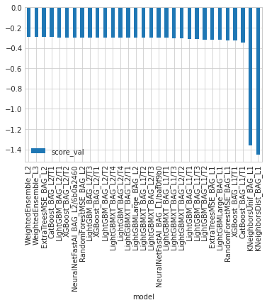

```python
# Output the model's `score_val` in a bar chart to compare performance
predictor_hpo.leaderboard(silent=True).plot(kind="bar", x="model", y="score_val")
plt.show()
```

```python
# Remember to set all negative values to zero
predictions_hpo = predictor_hpo.predict(test[test_col_names_2])
predictions_hpo = np.exp(predictions_hpo)
predictions_hpo[predictions_hpo<0] = 0
predictions_hpo.head()
```

```
0    8.902881
1    4.025856
2    2.618401
3    2.070541
4    1.835755
Name: log_count, dtype: float32
```

```python
# Same submitting predictions
submission_hpo = pd.read_csv("sampleSubmission.csv", parse_dates=["datetime"])
submission_hpo["count"] = predictions_hpo
submission_hpo.to_csv("submission_hpo.csv", index=False)
```

```python
!kaggle competitions submit -c bike-sharing-demand -f submission_hpo.csv -m "log count with hyperparameters"
```

```
Successfully submitted to Bike Sharing Demand
```

```python
!kaggle competitions submissions -c bike-sharing-demand | tail -n +1 | head -n 6
```

```
fileName                        date                 description                           status    publicScore  privateScore
------------------------------  -------------------  ------------------------------------  --------  -----------  ------------
submission_hpo.csv              2023-02-05 22:28:00  log count with hyperparameters        complete  0.39182      0.39182
submission_log.csv              2023-02-05 22:03:44  log count                             complete  0.39387      0.39387
submission_new_features.csv     2023-02-05 21:47:52  new features                          complete  0.43710      0.43710
submission.csv                  2023-02-05 21:36:44  first raw submission                  complete  1.80822      1.80822
tail: write error: Broken pipe
```

#### New Score of 0.39182

Alternatively, here I will specify the machine learning method, lightGBM, to test and the search spaces to utilize.

```python
# based on code example in https://auto.gluon.ai/stable/tutorials/tabular_prediction/tabular-indepth.html
import autogluon.core as ag

gbm_options = {  # specifies non-default hyperparameter values for lightGBM gradient boosted trees
    'num_boost_round':  ag.space.Categorical(50,100,150),   # number of boosting rounds/number of trees (controls training time of GBM models)
    'num_leaves': ag.space.Int(lower=25, upper=65, default=35),  # number of leaves in trees (integer hyperparameter)
    'max_depth':ag.space.Int(lower=3, upper=20, default=5)
}


hyperparameters = {
    'GBM':gbm_options
                  }

time_limit =15*60  # train various models for ~15 min
num_trials = 20  # try at most 20 different hyperparameter configurations for each type of model
search_strategy = 'auto'  # to tune hyperparameters using random search routine with a local scheduler

hyperparameter_tune_kwargs = {
    'num_trials': num_trials,
    'scheduler' : 'local',
    'searcher': search_strategy,
}
```

```python
predictor_gbm = TabularPredictor(label = "log_count", eval_metric = "root_mean_squared_error").fit(
    train_data=train[train_col_names_2],
     time_limit = time_limit,
     hyperparameters = hyperparameters,
     hyperparameter_tune_kwargs=hyperparameter_tune_kwargs,
    auto_stack = True
)
```

```
No path specified. Models will be saved in: "AutogluonModels/ag-20230206_041312/"
Warning: hyperparameter tuning is currently experimental and may cause the process to hang.
Stack configuration (auto_stack=True): num_stack_levels=1, num_bag_folds=8, num_bag_sets=20
Beginning AutoGluon training ... Time limit = 900s
AutoGluon will save models to "AutogluonModels/ag-20230206_041312/"
AutoGluon Version:  0.6.2
Python Version:     3.8.10
Operating System:   Linux
Platform Machine:   x86_64
Platform Version:   #1 SMP Fri Dec 9 09:57:03 UTC 2022
Train Data Rows:    10886
Train Data Columns: 12
Label Column: log_count
Preprocessing data ...
AutoGluon infers your prediction problem is: 'regression' (because dtype of label-column == float and many unique label-values observed).
	Label info (max, min, mean, stddev): (6.884486652042782, 0.0, 4.55256, 1.48904)
	If 'regression' is not the correct problem_type, please manually specify the problem_type parameter during predictor init (You may specify problem_type as one of: ['binary', 'multiclass', 'regression'])
Using Feature Generators to preprocess the data ...
Fitting AutoMLPipelineFeatureGenerator...
	Available Memory:                    1389.51 MB
	Train Data (Original)  Memory Usage: 0.51 MB (0.0% of available memory)
	Inferring data type of each feature based on column values. Set feature_metadata_in to manually specify special dtypes of the features.
	Stage 1 Generators:
		Fitting AsTypeFeatureGenerator...
			Note: Converting 3 features to boolean dtype as they only contain 2 unique values.
	Stage 2 Generators:
		Fitting FillNaFeatureGenerator...
	Stage 3 Generators:
		Fitting IdentityFeatureGenerator...
		Fitting CategoryFeatureGenerator...
			Fitting CategoryMemoryMinimizeFeatureGenerator...
	Stage 4 Generators:
		Fitting DropUniqueFeatureGenerator...
	Types of features in original data (raw dtype, special dtypes):
		('category', []) : 7 | ['day', 'day_of_week', 'hour', 'month', 'season', ...]
		('float', [])    : 3 | ['humidity', 'temp', 'windspeed']
		('int', [])      : 2 | ['holiday', 'workingday']
	Types of features in processed data (raw dtype, special dtypes):
		('category', [])  : 6 | ['day', 'day_of_week', 'hour', 'month', 'season', ...]
		('float', [])     : 3 | ['humidity', 'temp', 'windspeed']
```

[output cut: 170 more lines]

```
Fitted model: LightGBM_BAG_L2/T19 ...
	-0.3114	 = Validation score   (-root_mean_squared_error)
	21.48s	 = Training   runtime
	0.0s	 = Validation runtime
Fitted model: LightGBM_BAG_L2/T20 ...
	-0.3582	 = Validation score   (-root_mean_squared_error)
	22.58s	 = Training   runtime
	0.0s	 = Validation runtime
Completed 1/20 k-fold bagging repeats ...
Fitting model: WeightedEnsemble_L3 ... Training model for up to 360.0s of the 120.44s of remaining time.
	-0.3095	 = Validation score   (-root_mean_squared_error)
	0.29s	 = Training   runtime
	0.0s	 = Validation runtime
AutoGluon training complete, total runtime = 780.05s ... Best model: "WeightedEnsemble_L3"
TabularPredictor saved. To load, use: predictor = TabularPredictor.load("AutogluonModels/ag-20230206_041312/")
```

```python
# Remember to set all negative values to zero
predictions_gbm = predictor_gbm.predict(test[test_col_names_2])
predictions_gbm = np.exp(predictions_gbm)
predictions_gbm[predictions_gbm<0] = 0
predictions_gbm.head()
```

```
0    7.667453
1    3.892420
2    2.285994
3    1.874841
4    1.858926
Name: log_count, dtype: float32
```

```python
# Same submitting predictions
submission_gbm = pd.read_csv("sampleSubmission.csv", parse_dates=["datetime"])
submission_gbm["count"] = predictions_gbm
submission_gbm.to_csv("submission_gbm.csv", index=False)
```

```python
!kaggle competitions submit -c bike-sharing-demand -f submission_gbm.csv -m "gbm with hyperparameters"
```

```
Successfully submitted to Bike Sharing Demand
```

```python
!kaggle competitions submissions -c bike-sharing-demand | tail -n +1 | head -n 3
```

```
fileName                        date                 description                           status    publicScore  privateScore
------------------------------  -------------------  ------------------------------------  --------  -----------  ------------
submission_gbm.csv              2023-02-06 04:27:34  gbm with hyperparameters              complete  0.41853      0.41853
tail: write error: Broken pipe
```

## Step 7: Write a Report

### Refer to the markdown file for the full report

### Creating plots and table for report

I will manually calculate scores on the full training dataset here because some of the models above used 'count' variable as the predictand while the others used 'log_count' as the predictand. Please note that this is not a validation score.

```python
from sklearn.metrics import mean_squared_error as mse
rmse = []
rmse.append((-1)*np.sqrt(mse(train['count'], predictor.predict(train[train_col_names]))))
rmse.append((-1)*np.sqrt(mse(train['count'], predictor_new_features.predict(train[train_col_names_1]))))
rmse.append((-1)*np.sqrt(mse(train['count'], np.exp(predictor_log.predict(train[train_col_names_2])))))
rmse.append((-1)*np.sqrt(mse(train['count'], np.exp(predictor_hpo.predict(train[train_col_names_2])))))
```

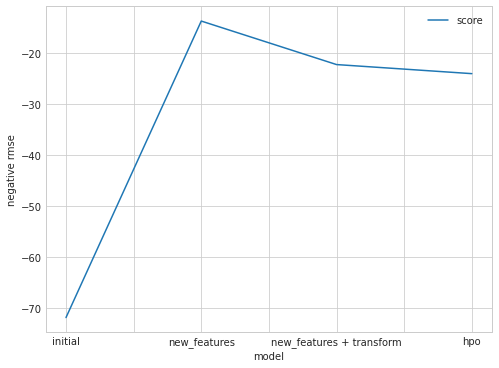

```python
# Taking the top model score from each training run and creating a line plot to show improvement
# You can create these in the notebook and save them to PNG or use some other tool (e.g. google sheets, excel)
fig = pd.DataFrame(
    {
        "model":  ["initial", "new_features", "new_features + transform", "hpo"],
        "score": rmse
    }
).plot(x="model", y="score", figsize=(8, 6)).get_figure()
plt.ylabel('negative rmse')
fig.savefig('model_train_score.png')
```

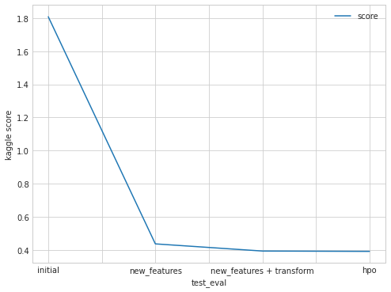

```python
# Take the 3 kaggle scores and creating a line plot to show improvement
fig = pd.DataFrame(
    {
        "test_eval": ["initial", "new_features", "new_features + transform", "hpo"],
        "score": [1.80822, 0.43710, 0.39387, 0.39182]
    }
).plot(x="test_eval", y="score", figsize=(8, 6)).get_figure()
plt.ylabel('kaggle score')
fig.savefig('model_test_score.png')
```

### Hyperparameter table

```python
# The 3 hyperparameters we tuned with the kaggle score as the result
pd.DataFrame({
    "model": ["initial", "new_features", "new_features + transform", "hpo"],
    "time_limit": ['10min','10min' , '10min', '30min'],
    "searcher": ['default', 'default', 'default', 'bayes'],
    "predictand_log_transform": ['False', 'False', 'True', 'True'],
    "score": [1.80822, 0.43710, 0.39387, 0.39182]
})
```

|  | model | time_limit | searcher | predictand_log_transform | score |
| --- | --- | --- | --- | --- | --- |
| 0 | initial | 10min | default | False | 1.80822 |
| 1 | new_features | 10min | default | False | 0.43710 |
| 2 | new_features + transform | 10min | default | True | 0.39387 |
| 3 | hpo | 30min | bayes | True | 0.39182 |